# Entrega Pablo Blas

2024-03-25

```r
library(ggplot2)
library(MASS)
library(gridExtra)
library(plyr)
library(e1071)
library(reshape2)
library(magrittr)
library(tidyr)
library(GGally)
library('huxtable')
library('jtools')
library(leaps)
library(car)
# install.packages("carData")
```

```r
# Cargar el dataset Boston
data(Boston)

# Exploración de los datos
str(Boston)
```

```
## 'data.frame':    506 obs. of  14 variables:
##  $ crim   : num  0.00632 0.02731 0.02729 0.03237 0.06905 ...
##  $ zn     : num  18 0 0 0 0 0 12.5 12.5 12.5 12.5 ...
##  $ indus  : num  2.31 7.07 7.07 2.18 2.18 2.18 7.87 7.87 7.87 7.87 ...
##  $ chas   : int  0 0 0 0 0 0 0 0 0 0 ...
##  $ nox    : num  0.538 0.469 0.469 0.458 0.458 0.458 0.524 0.524 0.524 0.524 ...
##  $ rm     : num  6.58 6.42 7.18 7 7.15 ...
##  $ age    : num  65.2 78.9 61.1 45.8 54.2 58.7 66.6 96.1 100 85.9 ...
##  $ dis    : num  4.09 4.97 4.97 6.06 6.06 ...
##  $ rad    : int  1 2 2 3 3 3 5 5 5 5 ...
##  $ tax    : num  296 242 242 222 222 222 311 311 311 311 ...
##  $ ptratio: num  15.3 17.8 17.8 18.7 18.7 18.7 15.2 15.2 15.2 15.2 ...
##  $ black  : num  397 397 393 395 397 ...
##  $ lstat  : num  4.98 9.14 4.03 2.94 5.33 ...
##  $ medv   : num  24 21.6 34.7 33.4 36.2 28.7 22.9 27.1 16.5 18.9 ...
```

```r
names(Boston)
```

```
##  [1] "crim"    "zn"      "indus"   "chas"    "nox"     "rm"      "age"
##  [8] "dis"     "rad"     "tax"     "ptratio" "black"   "lstat"   "medv"
```

```r
# Mínimo, primer cuartil, mediana, tercer cuartil y máximo.
summary_df <- data.frame(
  Variable = colnames(Boston),
  Mínimo = sapply(Boston, min),
  Primer_cuartil = sapply(Boston, quantile, probs = 0.25),
  Mediana = sapply(Boston, median),
  Tercer_cuartil = sapply(Boston, quantile, probs = 0.75),
  Máximo = sapply(Boston, max)
)
summary_df
```

| Variable | Mínimo | Primer_cuartil | Mediana | Tercer_cuartil | Máximo |
| --- | --- | --- | --- | --- | --- |
| crim | 0.00632 | 0.082 | 0.257 | 3.68 | 89 |
| zn | 0 | 0 | 0 | 12.5 | 100 |
| indus | 0.46 | 5.19 | 9.69 | 18.1 | 27.7 |
| chas | 0 | 0 | 0 | 0 | 1 |
| nox | 0.385 | 0.449 | 0.538 | 0.624 | 0.871 |
| rm | 3.56 | 5.89 | 6.21 | 6.62 | 8.78 |
| age | 2.9 | 45 | 77.5 | 94.1 | 100 |
| dis | 1.13 | 2.1 | 3.21 | 5.19 | 12.1 |
| rad | 1 | 4 | 5 | 24 | 24 |
| tax | 187 | 279 | 330 | 666 | 711 |
| ptratio | 12.6 | 17.4 | 19.1 | 20.2 | 22 |
| black | 0.32 | 375 | 391 | 396 | 397 |
| lstat | 1.73 | 6.95 | 11.4 | 17 | 38 |
| medv | 5 | 17 | 21.2 | 25 | 50 |

```r
# Estadísticas de las variables.
statistics_df <- data.frame(
  Variable = colnames(Boston),
  Media = sapply(Boston, mean),
  Mediana = sapply(Boston, median),
  Varianza = sapply(Boston, var),
  "Desviación estandar" = sapply(Boston, sd),
  "Coeficiente de asimetria" = sapply(Boston, skewness),
  Curtosis = sapply(Boston, kurtosis)
)
statistics_df
```

| Variable | Media | Mediana | Varianza | Desviación.estandar | Coeficiente.de.asimetria | Curtosis |
| --- | --- | --- | --- | --- | --- | --- |
| crim | 3.61 | 0.257 | 74 | 8.6 | 5.19 | 36.6 |
| zn | 11.4 | 0 | 544 | 23.3 | 2.21 | 3.95 |
| indus | 11.1 | 9.69 | 47.1 | 6.86 | 0.293 | -1.24 |
| chas | 0.0692 | 0 | 0.0645 | 0.254 | 3.39 | 9.48 |
| nox | 0.555 | 0.538 | 0.0134 | 0.116 | 0.725 | -0.0874 |
| rm | 6.28 | 6.21 | 0.494 | 0.703 | 0.401 | 1.84 |
| age | 68.6 | 77.5 | 792 | 28.1 | -0.595 | -0.978 |
| dis | 3.8 | 3.21 | 4.43 | 2.11 | 1.01 | 0.458 |
| rad | 9.55 | 5 | 75.8 | 8.71 | 0.999 | -0.879 |
| tax | 408 | 330 | 2.84e+04 | 169 | 0.666 | -1.15 |
| ptratio | 18.5 | 19.1 | 4.69 | 2.16 | -0.798 | -0.305 |
| black | 357 | 391 | 8.33e+03 | 91.3 | -2.87 | 7.1 |
| lstat | 12.7 | 11.4 | 51 | 7.14 | 0.901 | 0.463 |
| medv | 22.5 | 21.2 | 84.6 | 9.2 | 1.1 | 1.45 |

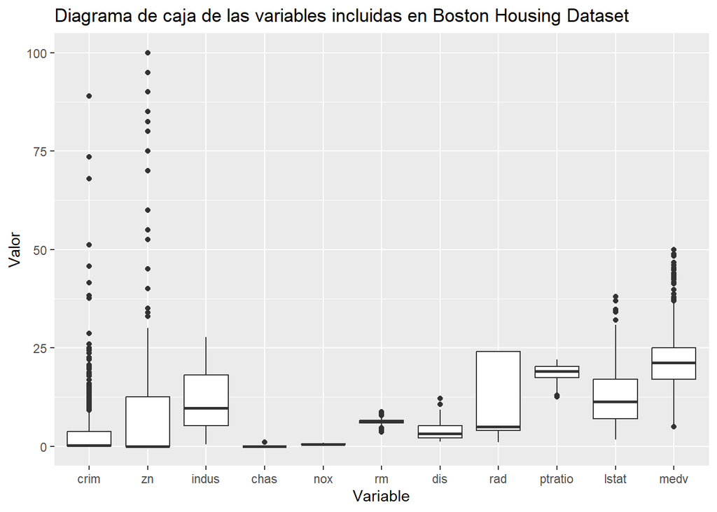

```r
df_boxplot <- as.data.frame(Boston[, !names(Boston) %in% c("black", "tax", "age")])

df_boxplot_melted <- reshape2::melt(df_boxplot)
ggplot(df_boxplot_melted, aes(x = variable, y = value)) +
  geom_boxplot() +
  labs(x = "Variable", y = "Valor", title = "Diagrama de caja de las variables incluidas en Boston Housing Dataset")
```

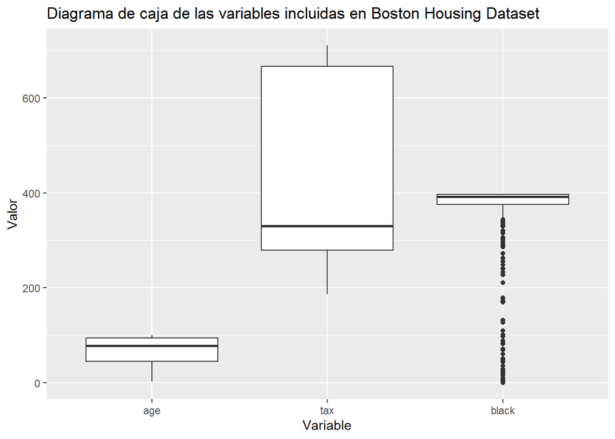

```r
df_boxplot <- as.data.frame(Boston[, names(Boston) %in% c("black", "tax", "age")])

df_boxplot_melted <- reshape2::melt(df_boxplot)
ggplot(df_boxplot_melted, aes(x = variable, y = value)) +
  geom_boxplot() +
  labs(x = "Variable", y = "Valor", title = "Diagrama de caja de las variables incluidas en Boston Housing Dataset")
```

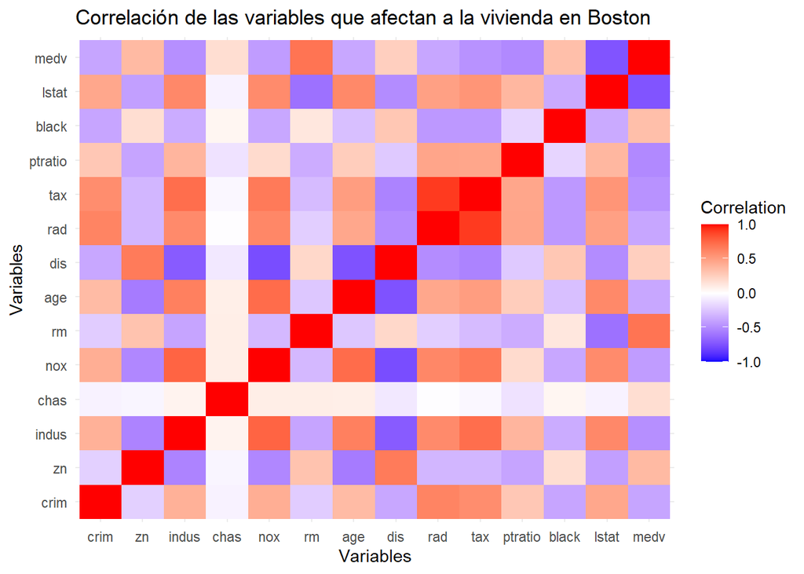

```r
# Calcular la matriz de correlación
correlation_matrix <- cor(Boston)

# Convertir la matriz de correlación a formato largo
correlation_data <- melt(correlation_matrix)

# Heatmap que muestra la intensidad de las correlaciones de las variables
ggplot(data = correlation_data, aes(x = Var1, y = Var2, fill = value)) +
  geom_tile() +
  scale_fill_gradient2(low = "blue", mid = "white", high = "red",
                       midpoint = 0, limit = c(-1, 1),
                       name = "Correlation") +
  labs(title = "Correlación de las variables que afectan a la vivienda en Boston",
       x = "Variables", y = "Variables") +
  theme(axis.text.x = element_text(angle = 45, hjust = 1)) +
  theme_minimal()
```

Debido a que existen regresores correlacionados entre ellos habrá que comprobar que los modelos esten libres del problema de multicolianealidad.

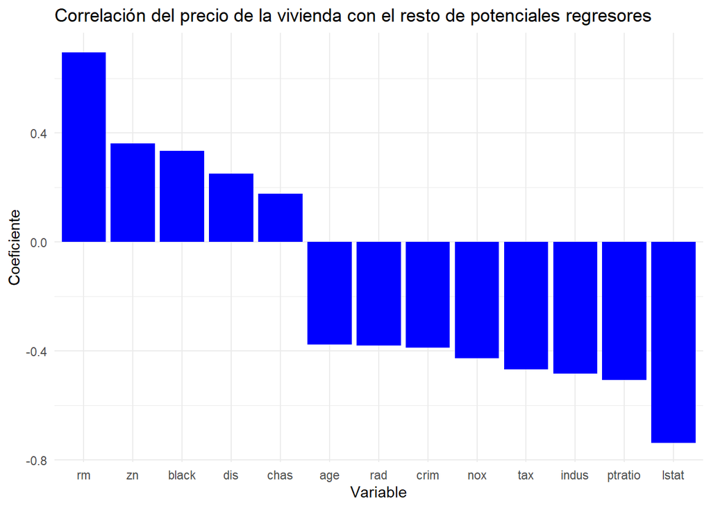

```r
correlation_df <-as.data.frame(correlation_matrix[,"medv"])

correlation_df <- correlation_df[-nrow(correlation_df), , drop = FALSE]
correlation_df$Variable <- rownames(correlation_df)
colnames(correlation_df) = c("Coeficiente_correlacion", "Variable")
correlation_df <- correlation_df[order(correlation_df$Coeficiente_correlacion), ]


ggplot(correlation_df, aes(x = reorder(Variable, -Coeficiente_correlacion), y = Coeficiente_correlacion, fill=Coeficiente_correlacion)) +
  geom_bar(stat = "identity", fill = "blue") +
  labs(title = "Correlación del precio de la vivienda con el resto de potenciales regresores",
       x = "Variable",
       y = "Coeficiente") +
  scale_fill_gradient2(low = "blue", mid = "white", high = "red",
                       midpoint = 0,
                       name = "Coeficiente_correlacion") +
  theme(axis.text.x = element_text(angle = 45, hjust = 1)) +
  theme_minimal()
```

Comprobamos la posible relación entre la variable de precio de vivienda y lstat mediante una tabla de contingencia simplificada.

```r
#TABLA DE CONTINGENCIA ENTRE LA VARIBALE TARGET MEDV Y LSTAT

tabla_contingencia = Boston[, c("medv", "lstat")]
tabla_contingencia$medv_breaks <-ifelse(Boston$medv<17, "Muy bajo", "NA")
tabla_contingencia$medv_breaks <-ifelse((Boston$medv>=17) & (Boston$medv<=21.2), "Bajo", tabla_contingencia$medv_breaks)
tabla_contingencia$medv_breaks <-ifelse((Boston$medv>21.2) & (Boston$medv<=25), "Alto", tabla_contingencia$medv_breaks)
tabla_contingencia$medv_breaks <-ifelse(Boston$medv>=25, "Muy alto", tabla_contingencia$medv_breaks)


tabla_contingencia$lstat_breaks <-ifelse(Boston$lstat<6.95, "Muy bajo", "NA")
tabla_contingencia$lstat_breaks <-ifelse((Boston$lstat>=6.95) & (Boston$lstat<=11.4), "Bajo", tabla_contingencia$lstat_breaks)
tabla_contingencia$lstat_breaks <-ifelse((Boston$lstat>11.4) & (Boston$lstat<=17), "Alto", tabla_contingencia$lstat_breaks)
tabla_contingencia$lstat_breaks <-ifelse(Boston$lstat>=17, "Muy alto", tabla_contingencia$lstat_breaks)





tabla_contingencia_final <- table(tabla_contingencia$lstat_breaks, tabla_contingencia$medv_breaks)



chi_square_test <- chisq.test(tabla_contingencia_final)
print(chi_square_test)
```

```
##
##  Pearson's Chi-squared test
##
## data:  tabla_contingencia_final
## X-squared = 460.11, df = 9, p-value < 2.2e-16
```

El p valor del test chi-squared es inferior a 0.05. Por lo tanto, sugiere que hay evidencia suficiente para rechazar la hipótesis nula, es decir, se rechaza la hipótesis nula de independencia entre las variables y se concluye que hay una asociación significativa entre las variables.

En este gráfico ordenamos los coeficientes de correlación de los posibles regresores de mayor a menor. A simple vista, las variables r y lstat obtienen valores absolutos significativamente superiores al resto de variables.

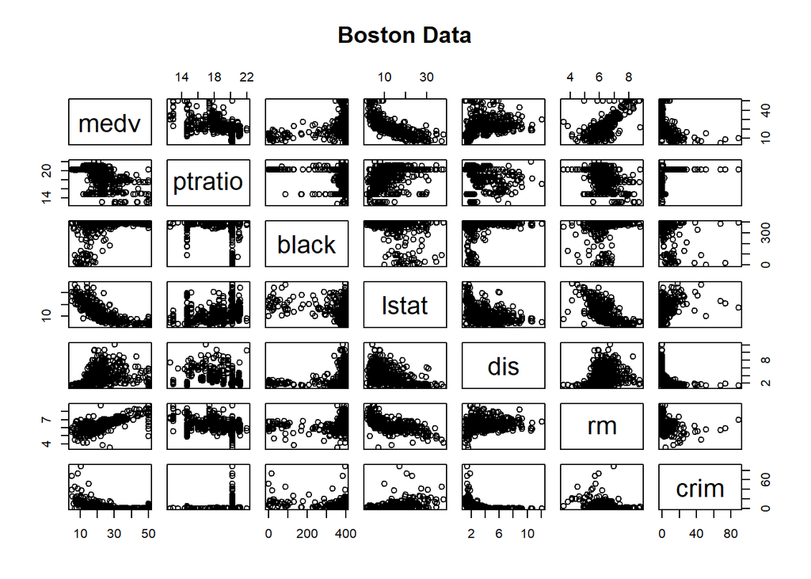

```r
# Relación de la variable medv con los potenciales regresores.
pairs(~ medv + ptratio + black + lstat + dis + rm + crim, data = Boston, main = "Boston Data")
```

lstat, dis y rm pueden tener potencialmente un fit lineal adecuado para la variable target (medv). El resto parecen no obtener una relación aparente con la variable independiente

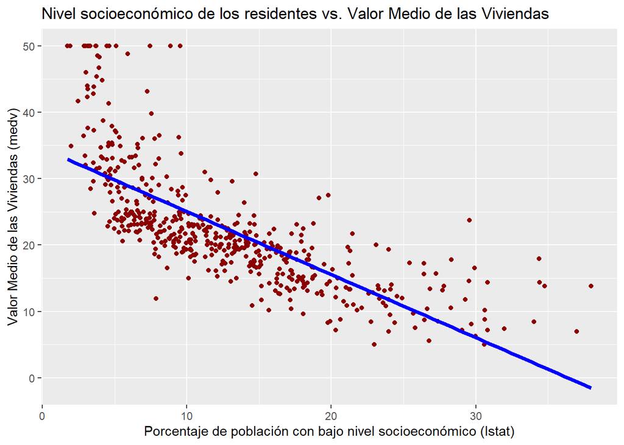

```r
# Dispersión medv-lstat (porcentaje de población con bajo status)
ggplot(Boston, aes(x = lstat, y = medv)) +
  geom_point(color = 'darkred', shape = 16) +
  geom_smooth(method = 'lm', formula = y ~ x, color = 'blue', size = 1.5, se = FALSE) +
  labs(x = 'Porcentaje de población con bajo nivel socioeconómico (lstat)',
       y = 'Valor Medio de las Viviendas (medv)',
       title = 'Nivel socioeconómico de los residentes vs. Valor Medio de las Viviendas')
```

En el diagrama de dispersión de las variables medv y lstat (porcentaje de población con bajo status) parece existir una relación negativa pero con una vertiente no lineal

Pasamos a realizar la primera prueba con un modelo simple de regresión lineal:

```r
lm.fit =lm(medv~lstat ,data=Boston )
summary(lm.fit)
```

```
##
## Call:
## lm(formula = medv ~ lstat, data = Boston)
##
## Residuals:
##     Min      1Q  Median      3Q     Max
## -15.168  -3.990  -1.318   2.034  24.500
##
## Coefficients:
##             Estimate Std. Error t value Pr(>|t|)
## (Intercept) 34.55384    0.56263   61.41   <2e-16 ***
## lstat       -0.95005    0.03873  -24.53   <2e-16 ***
## ---
## Signif. codes:  0 '***' 0.001 '**' 0.01 '*' 0.05 '.' 0.1 ' ' 1
##
## Residual standard error: 6.216 on 504 degrees of freedom
## Multiple R-squared:  0.5441, Adjusted R-squared:  0.5432
## F-statistic: 601.6 on 1 and 504 DF,  p-value: < 2.2e-16
```

Existe una relación lineal negativa demostrada por el coeficiente negativo de -0.95. Este coeficiente es significativo a un nivel de confianza del 99% ya que el p-value asociado es inferior a 0,01. El R2 ajustado es bastante eleveado pero el modelo puede augmentar su explicabilidad añadiendo regresores adicionales. En este caso, la variabilidad del precio mediano de la vivienda viene explicado en un 54% por la variabilidad del porcentaje de población con bajo estatus. Después de realizar el fit, analizamos el comportamiento de los residuos para discernir si existe algun patrón:

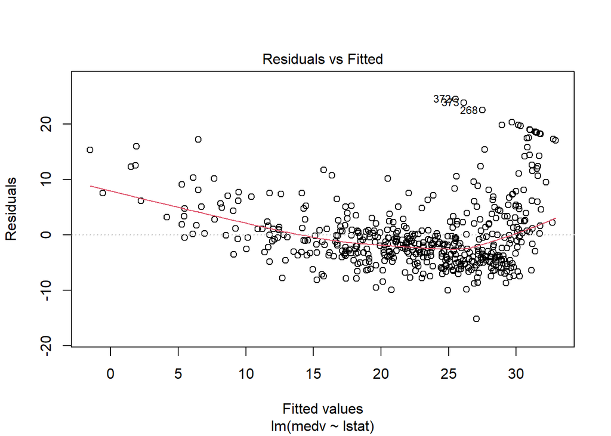

```r
residuos <- resid(lm.fit)
# Gráfico de residuos vs. valores ajustados
plot(lm.fit, which = 1)
```

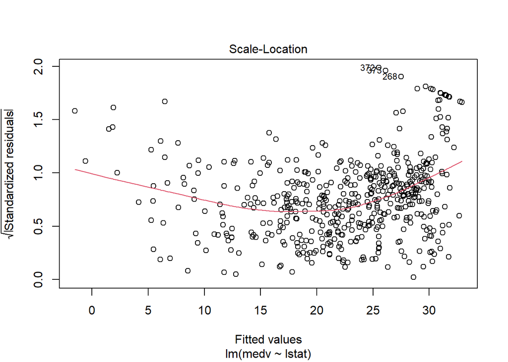

```r
# Gráfico de residuos estandarizados vs. valores ajustados
plot(lm.fit, which = 3)
```

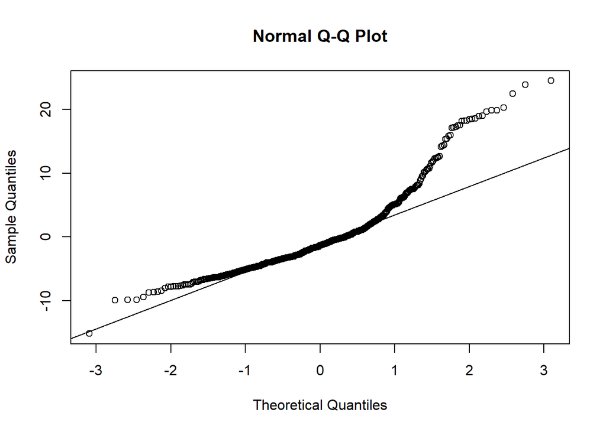

```r
# Gráfico Q-Q plot de los residuos estandarizados
qqnorm(residuos)
qqline(residuos)
```

El primer gráfico (grafico residuos vs. valores ajustados) ayuda a identificar si existe una relación entre los residuos y los valores ajustados, en este caso existe una relacion no lineal que no estamos captando y que también se ve reflejado en el segundo gráfico con los residuos estandarizados. En el segundo gráfico se puede identificar que existe cierta varianza en los residuos de los valores ajustados. Las características de la distribución de estos residuos también se pueden observar en el gráfico QQ-plot, existe cierta desviación respecto al ideal de distribución normal (puntos en la linea diagonal). Incorporamos la variable lstat^2 para captar esta información:

```r
Boston$lstat2 <- (Boston$lstat)^2

regfit.comparacion = regsubsets(medv~.,Boston, nvmax=10)
summary(regfit.comparacion)
```

```
## Subset selection object
## Call: regsubsets.formula(medv ~ ., Boston, nvmax = 10)
## 14 Variables  (and intercept)
##         Forced in Forced out
## crim        FALSE      FALSE
## zn          FALSE      FALSE
## indus       FALSE      FALSE
## chas        FALSE      FALSE
## nox         FALSE      FALSE
## rm          FALSE      FALSE
## age         FALSE      FALSE
## dis         FALSE      FALSE
## rad         FALSE      FALSE
## tax         FALSE      FALSE
## ptratio     FALSE      FALSE
## black       FALSE      FALSE
## lstat       FALSE      FALSE
## lstat2      FALSE      FALSE
## 1 subsets of each size up to 10
## Selection Algorithm: exhaustive
##           crim zn  indus chas nox rm  age dis rad tax ptratio black lstat
## 1  ( 1 )  " "  " " " "   " "  " " " " " " " " " " " " " "     " "   "*"
## 2  ( 1 )  " "  " " " "   " "  " " " " " " " " " " " " " "     " "   "*"
## 3  ( 1 )  " "  " " " "   " "  " " "*" " " " " " " " " " "     " "   "*"
## 4  ( 1 )  " "  " " " "   " "  " " "*" " " " " " " " " "*"     " "   "*"
## 5  ( 1 )  " "  " " " "   " "  " " "*" " " "*" " " " " "*"     " "   "*"
## 6  ( 1 )  "*"  " " " "   " "  " " "*" " " "*" " " " " "*"     " "   "*"
## 7  ( 1 )  "*"  " " " "   " "  "*" "*" " " "*" " " " " "*"     " "   "*"
## 8  ( 1 )  "*"  " " " "   "*"  "*" "*" " " "*" " " " " "*"     " "   "*"
## 9  ( 1 )  "*"  " " " "   "*"  "*" "*" " " "*" "*" " " "*"     " "   "*"
## 10  ( 1 ) "*"  " " " "   "*"  "*" "*" " " "*" "*" " " "*"     "*"   "*"
##           lstat2
## 1  ( 1 )  " "
## 2  ( 1 )  "*"
## 3  ( 1 )  "*"
## 4  ( 1 )  "*"
## 5  ( 1 )  "*"
## 6  ( 1 )  "*"
## 7  ( 1 )  "*"
## 8  ( 1 )  "*"
## 9  ( 1 )  "*"
## 10  ( 1 ) "*"
```

Nota del libro Introduction to Statistical Learning sobre este algoritmo: The `regsubsets()` function (part of the `leaps` library) performs best subset selection by identifying the best model that contains a given number of predictors, where *best* is quantified using RSS. The syntax is the same as for `lm()`. The `summary()` command outputs the best set of variables for each model size.

Teniendo en cuenta la información del algoritmo realizamos el resumen de regresiones para estas combinaciones

```r
correlation_df_aux = correlation_df
correlation_df_aux$Coeficiente_correlacion = abs(correlation_df_aux$Coeficiente_correlacion)
correlation_df_aux <- correlation_df_aux[order(correlation_df_aux$Coeficiente_correlacion), ]
correlation_df_aux$Variable
```

```
##  [1] "chas"    "dis"     "black"   "zn"      "age"     "rad"     "crim"
##  [8] "nox"     "tax"     "indus"   "ptratio" "rm"      "lstat"
```

```r
# Ordenamos las variables por su coeficiente de correlación en valor absoluto con la variable dependiente (correlation_df$Variable):

regresionlmultiple1 = lm(medv~chas+dis+black+zn+age+rad+crim+nox+tax+indus+ptratio+rm+lstat+lstat2, data=Boston)
regresionlmultiple2 = update(regresionlmultiple1, .~.-chas)
anova(regresionlmultiple1,regresionlmultiple2)
```

| Res.Df | RSS | Df | Sum of Sq | F | Pr(>F) |
| --- | --- | --- | --- | --- | --- |
| 491 | 8.99e+03 |  |  |  |  |
| 492 | 9.17e+03 | -1 | -178 | 9.7 | 0.00195 |

```r
regresionlmultiple3 = update(regresionlmultiple2, .~.-dis)
anova(regresionlmultiple2,regresionlmultiple3)
```

| Res.Df | RSS | Df | Sum of Sq | F | Pr(>F) |
| --- | --- | --- | --- | --- | --- |
| 492 | 9.17e+03 |  |  |  |  |
| 493 | 9.97e+03 | -1 | -797 | 42.7 | 1.57e-10 |

```r
regresionlmultiple4 = update(regresionlmultiple3, .~.-black)
anova(regresionlmultiple3,regresionlmultiple4)
```

| Res.Df | RSS | Df | Sum of Sq | F | Pr(>F) |
| --- | --- | --- | --- | --- | --- |
| 493 | 9.97e+03 |  |  |  |  |
| 494 | 1.02e+04 | -1 | -220 | 10.9 | 0.00104 |

```r
regresionlmultiple5 = update(regresionlmultiple4, .~.-zn)
anova(regresionlmultiple4,regresionlmultiple5)
```

| Res.Df | RSS | Df | Sum of Sq | F | Pr(>F) |
| --- | --- | --- | --- | --- | --- |
| 494 | 1.02e+04 |  |  |  |  |
| 495 | 1.02e+04 | -1 | -13 | 0.63 | 0.428 |

```r
regresionlmultiple6 = update(regresionlmultiple5, .~.-age)
anova(regresionlmultiple5,regresionlmultiple6)
```

| Res.Df | RSS | Df | Sum of Sq | F | Pr(>F) |
| --- | --- | --- | --- | --- | --- |
| 495 | 1.02e+04 |  |  |  |  |
| 496 | 1.08e+04 | -1 | -563 | 27.3 | 2.53e-07 |

```r
regresionlmultiple7 = update(regresionlmultiple6, .~.-rad)
anova(regresionlmultiple6,regresionlmultiple7)
```

| Res.Df | RSS | Df | Sum of Sq | F | Pr(>F) |
| --- | --- | --- | --- | --- | --- |
| 496 | 1.08e+04 |  |  |  |  |
| 497 | 1.12e+04 | -1 | -474 | 21.8 | 3.81e-06 |

```r
regresionlmultiple8 = update(regresionlmultiple7, .~.-crim)
anova(regresionlmultiple7,regresionlmultiple8)
```

| Res.Df | RSS | Df | Sum of Sq | F | Pr(>F) |
| --- | --- | --- | --- | --- | --- |
| 497 | 1.12e+04 |  |  |  |  |
| 498 | 1.15e+04 | -1 | -240 | 10.6 | 0.00121 |

```r
regresionlmultiple9 = update(regresionlmultiple8, .~.-nox)
anova(regresionlmultiple8,regresionlmultiple9)
```

| Res.Df | RSS | Df | Sum of Sq | F | Pr(>F) |
| --- | --- | --- | --- | --- | --- |
| 498 | 1.15e+04 |  |  |  |  |
| 499 | 1.15e+04 | -1 | -0.33 | 0.0143 | 0.905 |

```r
regresionlmultiple10 = update(regresionlmultiple9, .~.-tax)
anova(regresionlmultiple9,regresionlmultiple10)
```

| Res.Df | RSS | Df | Sum of Sq | F | Pr(>F) |
| --- | --- | --- | --- | --- | --- |
| 499 | 1.15e+04 |  |  |  |  |
| 500 | 1.16e+04 | -1 | -104 | 4.53 | 0.0338 |

```r
regresionlmultiple11 = update(regresionlmultiple10, .~.-indus)
anova(regresionlmultiple10,regresionlmultiple11)
```

| Res.Df | RSS | Df | Sum of Sq | F | Pr(>F) |
| --- | --- | --- | --- | --- | --- |
| 500 | 1.16e+04 |  |  |  |  |
| 501 | 1.17e+04 | -1 | -84.2 | 3.64 | 0.0571 |

```r
regresionlmultiple12 = update(regresionlmultiple11, .~.-ptratio)
anova(regresionlmultiple11,regresionlmultiple12)
```

| Res.Df | RSS | Df | Sum of Sq | F | Pr(>F) |
| --- | --- | --- | --- | --- | --- |
| 501 | 1.17e+04 |  |  |  |  |
| 502 | 1.27e+04 | -1 | -1.02e+03 | 43.6 | 1.01e-10 |

```r
regresionlmultiple13 = update(regresionlmultiple12, .~.-rm)
anova(regresionlmultiple12,regresionlmultiple13)
```

| Res.Df | RSS | Df | Sum of Sq | F | Pr(>F) |
| --- | --- | --- | --- | --- | --- |
| 502 | 1.27e+04 |  |  |  |  |
| 503 | 1.53e+04 | -1 | -2.66e+03 | 105 | 1.41e-22 |

```r
regresionlmultiple14 = update(regresionlmultiple12, .~.-lstat)
anova(regresionlmultiple13,regresionlmultiple14)
```

| Res.Df | RSS | Df | Sum of Sq | F | Pr(>F) |
| --- | --- | --- | --- | --- | --- |
| 503 | 1.53e+04 |  |  |  |  |
| 503 | 1.85e+04 | 0 | -3.13e+03 |  |  |

```r
# Podemos exportarlo a html y hacer una captura para que sea más facil de comparar
export_summs(regresionlmultiple1, regresionlmultiple2, regresionlmultiple3, regresionlmultiple4, regresionlmultiple5, regresionlmultiple6, regresionlmultiple7, regresionlmultiple8, regresionlmultiple9, regresionlmultiple10, regresionlmultiple11, regresionlmultiple12, regresionlmultiple13, regresionlmultiple14, model.names = c("Modelo 1", "Modelo 2", "Modelo 3", "Modelo 4", "Modelo 5", "Modelo 6", "Modelo 7", "Modelo 8", "Modelo 9", "Modelo 10", "Modelo11", "Modelo12", "Modelo13", "Modelo14"), stars = c(`***` = 0.01, `**` = 0.05, `*` = 0.1), statistics = c('Adj.R2' = 'adj.r.squared'),  to.file = "HTML", file.name = "Comparación de modelos.html")
```

|  | Modelo 1 | Modelo 2 | Modelo 3 | Modelo 4 | Modelo 5 | Modelo 6 | Modelo 7 | Modelo 8 | Modelo 9 | Modelo 10 | Modelo11 | Modelo12 | Modelo13 | Modelo14 |
| --- | --- | --- | --- | --- | --- | --- | --- | --- | --- | --- | --- | --- | --- | --- |
| (Intercept) | 43.58 *** | 44.04 *** | 34.00 *** | 38.74 *** | 37.96 *** | 31.31 *** | 23.74 *** | 25.14 *** | 25.31 *** | 26.54 *** | 25.78 *** | 11.69 *** | 42.86 *** | -16.31 *** |
|  | (4.65) | (4.69) | (4.62) | (4.43) | (4.32) | (4.23) | (3.99) | (4.01) | (3.74) | (3.70) | (3.69) | (3.14) | (0.87) | (3.06) |
| chas | 2.42 *** |  |  |  |  |  |  |  |  |  |  |  |  |  |
|  | (0.78) |  |  |  |  |  |  |  |  |  |  |  |  |  |
| dis | -1.19 *** | -1.20 *** |  |  |  |  |  |  |  |  |  |  |  |  |
|  | (0.18) | (0.18) |  |  |  |  |  |  |  |  |  |  |  |  |
| black | 0.01 *** | 0.01 *** | 0.01 *** |  |  |  |  |  |  |  |  |  |  |  |
|  | (0.00) | (0.00) | (0.00) |  |  |  |  |  |  |  |  |  |  |  |
| zn | 0.02 ** | 0.03 ** | -0.01 | -0.01 |  |  |  |  |  |  |  |  |  |  |
|  | (0.01) | (0.01) | (0.01) | (0.01) |  |  |  |  |  |  |  |  |  |  |
| age | 0.03 ** | 0.03 ** | 0.06 *** | 0.06 *** | 0.06 *** |  |  |  |  |  |  |  |  |  |
|  | (0.01) | (0.01) | (0.01) | (0.01) | (0.01) |  |  |  |  |  |  |  |  |  |
| rad | 0.29 *** | 0.31 *** | 0.32 *** | 0.31 *** | 0.31 *** | 0.30 *** |  |  |  |  |  |  |  |  |
|  | (0.06) | (0.06) | (0.06) | (0.06) | (0.06) | (0.06) |  |  |  |  |  |  |  |  |
| crim | -0.15 *** | -0.16 *** | -0.14 *** | -0.15 *** | -0.15 *** | -0.14 *** | -0.10 *** |  |  |  |  |  |  |  |
|  | (0.03) | (0.03) | (0.03) | (0.03) | (0.03) | (0.03) | (0.03) |  |  |  |  |  |  |  |
| nox | -16.28 *** | -15.91 *** | -9.43 *** | -10.23 *** | -9.76 *** | -1.96 | 0.87 | 0.39 |  |  |  |  |  |  |
|  | (3.45) | (3.48) | (3.47) | (3.50) | (3.44) | (3.19) | (3.19) | (3.22) |  |  |  |  |  |  |
| tax | -0.01 *** | -0.01 *** | -0.01 *** | -0.01 *** | -0.01 *** | -0.01 *** | -0.00 | -0.00 ** | -0.00 ** |  |  |  |  |  |
|  | (0.00) | (0.00) | (0.00) | (0.00) | (0.00) | (0.00) | (0.00) | (0.00) | (0.00) |  |  |  |  |  |
| indus | 0.05 | 0.06 | 0.14 ** | 0.14 ** | 0.15 *** | 0.19 *** | 0.12 ** | 0.13 ** | 0.14 *** | 0.08 * |  |  |  |  |
|  | (0.06) | (0.06) | (0.06) | (0.06) | (0.06) | (0.06) | (0.06) | (0.06) | (0.05) | (0.04) |  |  |  |  |
| ptratio | -0.82 *** | -0.85 *** | -0.91 *** | -0.90 *** | -0.87 *** | -0.80 *** | -0.68 *** | -0.69 *** | -0.70 *** | -0.77 *** | -0.73 *** |  |  |  |
|  | (0.12) | (0.12) | (0.12) | (0.12) | (0.12) | (0.12) | (0.12) | (0.12) | (0.12) | (0.11) | (0.11) |  |  |  |
| rm | 3.04 *** | 3.07 *** | 3.33 *** | 3.19 *** | 3.16 *** | 3.72 *** | 4.01 *** | 3.97 *** | 3.97 *** | 3.85 *** | 3.88 *** | 4.23 *** |  | 6.63 *** |
|  | (0.38) | (0.39) | (0.40) | (0.40) | (0.40) | (0.40) | (0.40) | (0.40) | (0.40) | (0.40) | (0.40) | (0.41) |  | (0.46) |
| lstat | -1.77 *** | -1.79 *** | -1.92 *** | -1.97 *** | -1.96 *** | -1.74 *** | -1.75 *** | -1.72 *** | -1.72 *** | -1.73 *** | -1.65 *** | -1.85 *** | -2.33 *** |  |
|  | (0.13) | (0.13) | (0.13) | (0.13) | (0.13) | (0.13) | (0.13) | (0.13) | (0.13) | (0.13) | (0.12) | (0.12) | (0.12) |  |
| lstat2 | 0.03 *** | 0.04 *** | 0.04 *** | 0.04 *** | 0.04 *** | 0.03 *** | 0.04 *** | 0.03 *** | 0.03 *** | 0.03 *** | 0.03 *** | 0.04 *** | 0.04 *** | -0.01 *** |
|  | (0.00) | (0.00) | (0.00) | (0.00) | (0.00) | (0.00) | (0.00) | (0.00) | (0.00) | (0.00) | (0.00) | (0.00) | (0.00) | (0.00) |
| Adj.R2 | 0.78 | 0.78 | 0.76 | 0.76 | 0.76 | 0.74 | 0.73 | 0.73 | 0.73 | 0.73 | 0.72 | 0.70 | 0.64 | 0.57 |
| *** p < 0.01; ** p < 0.05; * p < 0.1. |  |  |  |  |  |  |  |  |  |  |  |  |  |  |

Podemos observar como la métrica del R2 ajustado, que corrige el R2 estandard para evitar añadir variables que no aporten suficiente información para la variable dependiente, aumenta con cada regresor que añadimos pero de forma decreciente a partir del modelo con 3 regresores. Las estrellas nos indican el nivel de significación y el numero entre parentesis representa el error de estandard. Como podemos observar casi todas las variables son significativas y distintas de 0 a un nivel de significación del 99%.

Modelo final segun el anova empezando por con un modelo con todas las variables medv ~ age + rad + crim + nox + tax + indus + ptratio + rm + lstat + lstat2

```r
summary(regresionlmultiple5)
```

```
##
## Call:
## lm(formula = medv ~ age + rad + crim + nox + tax + indus + ptratio +
##     rm + lstat + lstat2, data = Boston)
##
## Residuals:
##      Min       1Q   Median       3Q      Max
## -15.6943  -2.8079  -0.4346   1.9408  26.4576
##
## Coefficients:
##              Estimate Std. Error t value Pr(>|t|)
## (Intercept) 37.955365   4.316949   8.792  < 2e-16 ***
## age          0.061925   0.011844   5.228 2.53e-07 ***
## rad          0.312699   0.062477   5.005 7.78e-07 ***
## crim        -0.150608   0.031273  -4.816 1.95e-06 ***
## nox         -9.759260   3.444445  -2.833  0.00479 **
## tax         -0.013584   0.003453  -3.934 9.53e-05 ***
## indus        0.148106   0.055854   2.652  0.00827 **
## ptratio     -0.869033   0.119761  -7.256 1.55e-12 ***
## rm           3.157688   0.400668   7.881 2.08e-14 ***
## lstat       -1.957427   0.130098 -15.046  < 2e-16 ***
## lstat2       0.038673   0.003394  11.395  < 2e-16 ***
## ---
## Signif. codes:  0 '***' 0.001 '**' 0.01 '*' 0.05 '.' 0.1 ' ' 1
##
## Residual standard error: 4.54 on 495 degrees of freedom
## Multiple R-squared:  0.7612, Adjusted R-squared:  0.7564
## F-statistic: 157.8 on 10 and 495 DF,  p-value: < 2.2e-16
```

Debido a que incorporamos un número elevado de regresores, conviene hacer un test de multicolinealidad para comprobar la estabilidad del modelo y esto lo haremos con el Variance Inflation Factor:

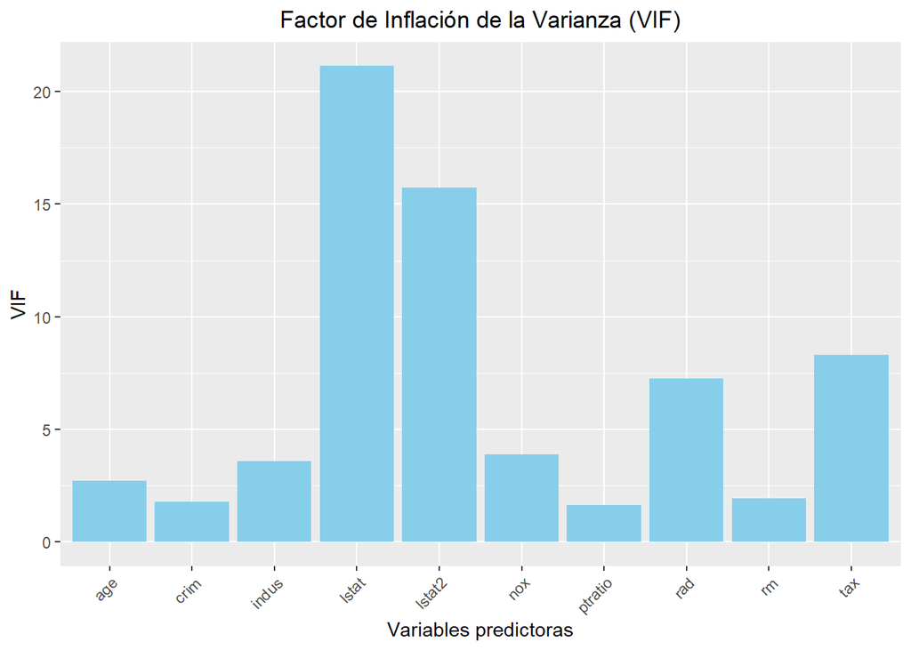

```r
vif_df_fit5 <- data.frame(Variables = names(vif(regresionlmultiple5)), VIF = as.numeric(vif(regresionlmultiple5)))

vif_df_fit5 <- vif_df_fit5[order(vif_df_fit5$VIF, decreasing = TRUE), ]

ggplot(vif_df_fit5, aes(x = Variables, y = VIF)) +
  geom_bar(stat = "identity", fill = "skyblue") +
  labs(title = "Factor de Inflación de la Varianza (VIF)",
       x = "Variables predictoras",
       y = "VIF") +
  theme(axis.text.x = element_text(angle = 45, hjust = 1),
        plot.title = element_text(hjust = 0.5))
```

Como podemos observar los valores VIF son superiores a 10 en lstat y su tranformación al cuadrado. Esto indica de forma evidente multicolinealidad fuerte y complica la interpretación de los coeficientes de regresión debido a la alta correlación entre las variables predictoras. Addicionalmente, los coeficientes individuales pueden ser imprecisos y difíciles de interpretar.

Por lo tanto, para solventar problemas de estabilidad de modelo, eliminamos lstat y obtenemos valores más razonables:

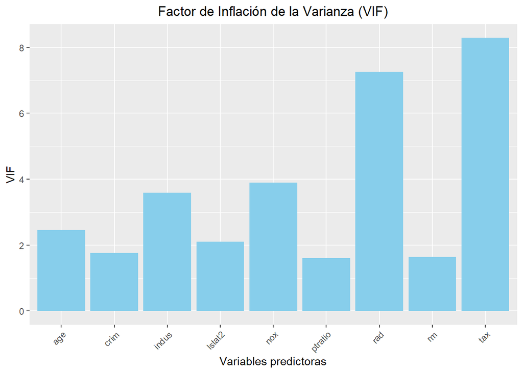

```r
regresionlmultiple5_aux = lm(medv~age + rad + crim + nox + tax + indus + ptratio + rm + lstat2, data=Boston)
vif_df_fit5_aux <- data.frame(Variables = names(vif(regresionlmultiple5_aux)), VIF = as.numeric(vif(regresionlmultiple5_aux)))

vif_df_fit5_aux <- vif_df_fit5_aux[order(vif_df_fit5_aux$VIF, decreasing = TRUE), ]

ggplot(vif_df_fit5_aux, aes(x = Variables, y = VIF)) +
  geom_bar(stat = "identity", fill = "skyblue") +
  labs(title = "Factor de Inflación de la Varianza (VIF)",
       x = "Variables predictoras",
       y = "VIF") +
  theme(axis.text.x = element_text(angle = 45, hjust = 1),
        plot.title = element_text(hjust = 0.5))
```

Analisis de residuos del modelo final

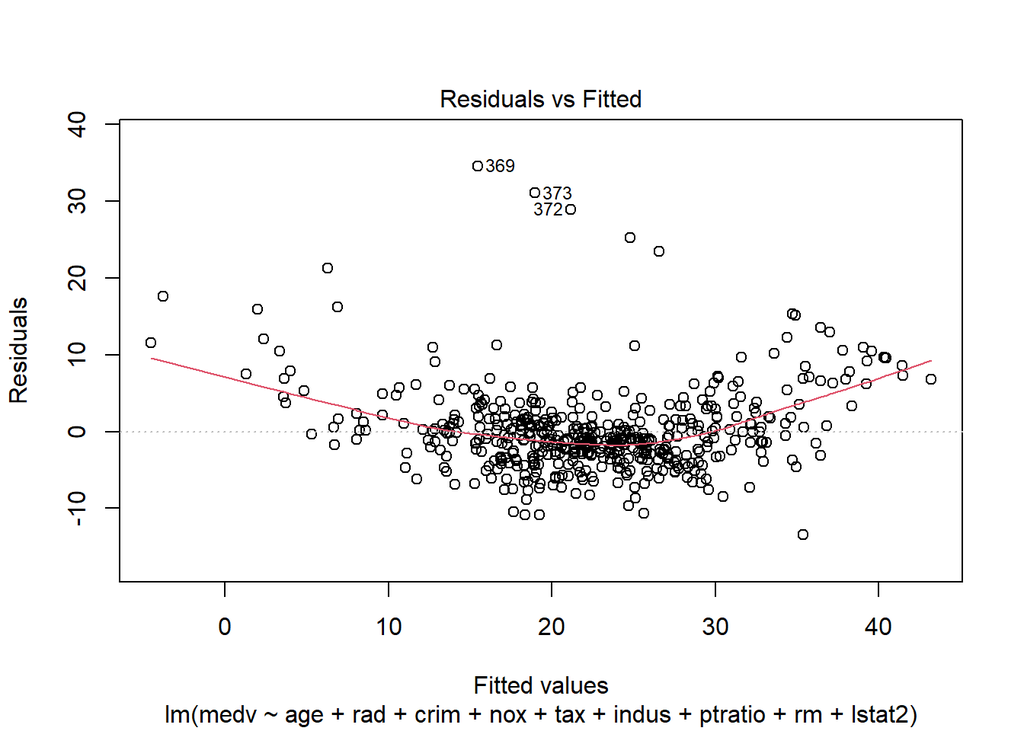

```r
residuos <- resid(regresionlmultiple5_aux)
# Gráfico de residuos vs. valores ajustados
plot(regresionlmultiple5_aux, which = 1)
```

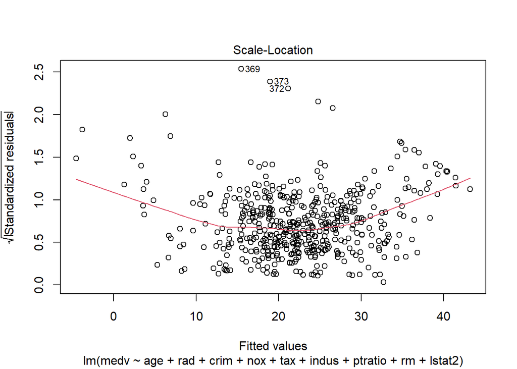

```r
# Gráfico de residuos estandarizados vs. valores ajustados
plot(regresionlmultiple5_aux, which = 3)
```

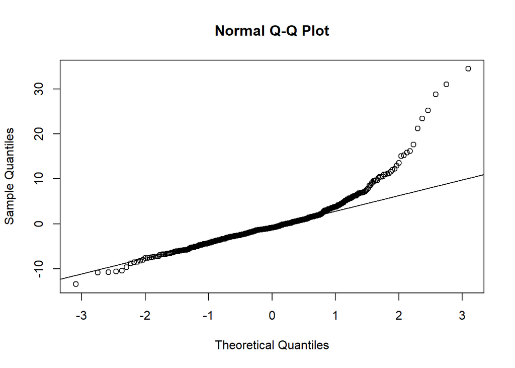

```r
# Gráfico Q-Q plot de los residuos estandarizados
qqnorm(residuos)
qqline(residuos)
```

En el primer gráfico, podemos observar como aunque obtiene un patrón ligeramente curvado, tiene residuos igualmente distribuidos alrededor de la línea horizontal sin un número significativo (3) de observaciones atipicas destacables.

```r
library(lmtest)
bptest(regresionlmultiple5_aux)
```

```
##
##  studentized Breusch-Pagan test
##
## data:  regresionlmultiple5_aux
## BP = 44.235, df = 9, p-value = 1.277e-06
```

El pvalor es inferior a 0.05 y, por lo tanto, rechazamos la hipotesis nula de homoscedasticidad y existen indicios de heteroskedasciticidad y la variabilidad de los errores no es constante en todos los niveles de los regresores.Para corregirlo, utilizamos un ajuste lineal con corrección de errores (errores estandares robustos) y los coeficientes són los siguientes:

```r
library(sandwich)
coeftest(regresionlmultiple5_aux, vcov = vcovHC(regresionlmultiple5_aux, "HC1"))
```

```
##
## t test of coefficients:
##
##                Estimate  Std. Error t value  Pr(>|t|)
## (Intercept)  19.7367465   7.2496195  2.7225  0.006708 **
## age           0.0060837   0.0149271  0.4076  0.683775
## rad           0.3063803   0.0731980  4.1856 3.364e-05 ***
## crim         -0.1173988   0.0277539 -4.2300 2.784e-05 ***
## nox         -11.9052879   3.9271527 -3.0315  0.002560 **
## tax          -0.0148934   0.0027963 -5.3261 1.524e-07 ***
## indus         0.1046465   0.0530271  1.9735  0.048998 *
## ptratio      -1.1595594   0.1310296 -8.8496 < 2.2e-16 ***
## rm            5.5153621   0.8408315  6.5594 1.360e-10 ***
## lstat2       -0.0088438   0.0028628 -3.0892  0.002120 **
## ---
## Signif. codes:  0 '***' 0.001 '**' 0.01 '*' 0.05 '.' 0.1 ' ' 1
```